# Principal Component Analysis (PCA) dan Factor Analysis (FA) pada Data Kanker Payudara

Ismatul Izza(23031554226) , Fherenilla Anandianus (23031554205)

2025-03-22

# 1 BAB Pendahuluan

## 1.1 Latar Belakang

Kanker payudara adalah penyakit yang disebabkan oleh pertumbuhan sel payudara yang tumbuh tak terkendali dan membentuk tumor jika tidak ditangani dapat keseluruh Tubuh dan berakibat fatal ( WHO, 2024).Tercatat pada 2022 ada 2.3 juta perempuan yang terdiagnosis kanker payudara dan 670.000 diantaranya meninggal di seluruh dunia ( WHO, 2024). Berdasarkan Global Cancer Observatory, di Indonesia, kanker payudara menjadi jenis kanker yang paling umum terjadi, dengan jumlah kasus baru mencapai 65.858 (16,6%) dari total 396.914 kasus baru kanker pada tahun 2020 ( Winasis A., 2024 ). Dengan meningkatnya jumlah kasus kanker payudara diperlukan metode yang dapat membantu dalam menganalisis faktor risiko ,diagnosis dini, dan pengelompokan karakteristik secara lebih efektif. Salah satu metode yang digunakan dalam diagnosis kanker payudara adalah Fine needle Aspiration (FNA). Fine needle Aspiration (FNA) merupakan prosedur sederhana untuk diagnosis sitologi cepat pada lesi payudara (Tagar E., 2024). Dataset Wisconsin Breast Cancer Database (WBCD) yang tersedia di UCI Machine Learning Repository merupakan kumpulan data hasil ekstraksi fitur dari citra digitalisasi FNA. Fitur-fitur ini merepresentasikan karakteristik inti sel yang terdapat dalam gambar dan digunakan untuk membedakan antara tumor jinak dan ganas. Untuk meningkatkan akurasi klasifikasi kanker payudara Principal Component Analysis (PCA) dan exploratory Factor Analysis (EFA) dapat digunakan sebagai teknik analisis data.Principal Component Analysis (PCA) adalah metode statistika untuk mereduksi tabel data kasus per variable menjadi fitur-fitur Penting yang disebut komponen utama ( Greencare M., 2022).Sementara itu Exploratory Factor Analysis adalah teknik statistik yang digunakan untuk mengungkap struktur yang mendasari dalam sekumpulan besar variabel. Metode ini bertujuan untuk mendeteksi hubungan mendasar di antara variabel yang diukur dengan mengidentifikasi konstruk laten yang menjelaskan interkoneksinya(Rijukure , 2024). Melalui penelitian ini, PCA dan FA akan diterapkan pada dataset kanker payudara dari UCI untuk meningkatkan interpretabilitas data dan akurasi model klasifikasi, guna mendukung pengambilan keputusan dalam diagnosis kanker payudara.

# 2 BAB Metodologi Penelitian

## 2.1 DATA

[output not shown]

```r
data <- read.csv('/cloud/python/FAanalysis/brest_cancer_uci.csv')
print(data)
```

```
##     radius1 texture1 perimeter1  area1 smoothness1 compactness1 concavity1
## 1    17.990    10.38     122.80 1001.0     0.11840      0.27760  0.3001000
## 2    20.570    17.77     132.90 1326.0     0.08474      0.07864  0.0869000
## 3    19.690    21.25     130.00 1203.0     0.10960      0.15990  0.1974000
## 4    11.420    20.38      77.58  386.1     0.14250      0.28390  0.2414000
## 5    20.290    14.34     135.10 1297.0     0.10030      0.13280  0.1980000
## 6    12.450    15.70      82.57  477.1     0.12780      0.17000  0.1578000
## 7    18.250    19.98     119.60 1040.0     0.09463      0.10900  0.1127000
## 8    13.710    20.83      90.20  577.9     0.11890      0.16450  0.0936600
## 9    13.000    21.82      87.50  519.8     0.12730      0.19320  0.1859000
## 10   12.460    24.04      83.97  475.9     0.11860      0.23960  0.2273000
## 11   16.020    23.24     102.70  797.8     0.08206      0.06669  0.0329900
## 12   15.780    17.89     103.60  781.0     0.09710      0.12920  0.0995400
## 13   19.170    24.80     132.40 1123.0     0.09740      0.24580  0.2065000
## 14   15.850    23.95     103.70  782.7     0.08401      0.10020  0.0993800
```

[output cut: 2835 more lines]

## 2.2 Variabel

Variabel yang digunakan berasal dari jaringan payudara pasien meliputi: 1. radius1, radius2, radius3 2. texture1, texture2, texture3 3. perimeter1, perimeter2, perimeter3 4. area1,area2, area3 5. smoothness1, smoothness2, smoothness3 6. compactness1, compactness2, compactness3 7. concavity1, concavity2, concavity3 8. concave_points1, concave_points2, concave_points3 9. symmetry1, symmetry2, symmetry3 10. fractal_dimension1, fractal_dimension2, fractal_dimension3

preprocessing

```r
sum(is.na(data))
```

```
## [1] 0
```

```r
p <- ncol(data)
```

# 3 BAB Pembahasan

## 3.1 Statistika Deskriptiv

```r
summary(data)
```

```
##     radius1          texture1       perimeter1         area1
##  Min.   : 6.981   Min.   : 9.71   Min.   : 43.79   Min.   : 143.5
##  1st Qu.:11.700   1st Qu.:16.17   1st Qu.: 75.17   1st Qu.: 420.3
##  Median :13.370   Median :18.84   Median : 86.24   Median : 551.1
##  Mean   :14.127   Mean   :19.29   Mean   : 91.97   Mean   : 654.9
##  3rd Qu.:15.780   3rd Qu.:21.80   3rd Qu.:104.10   3rd Qu.: 782.7
##  Max.   :28.110   Max.   :39.28   Max.   :188.50   Max.   :2501.0
##   smoothness1       compactness1       concavity1      concave_points1
##  Min.   :0.05263   Min.   :0.01938   Min.   :0.00000   Min.   :0.00000
##  1st Qu.:0.08637   1st Qu.:0.06492   1st Qu.:0.02956   1st Qu.:0.02031
##  Median :0.09587   Median :0.09263   Median :0.06154   Median :0.03350
##  Mean   :0.09636   Mean   :0.10434   Mean   :0.08880   Mean   :0.04892
##  3rd Qu.:0.10530   3rd Qu.:0.13040   3rd Qu.:0.13070   3rd Qu.:0.07400
##  Max.   :0.16340   Max.   :0.34540   Max.   :0.42680   Max.   :0.20120
##    symmetry1      fractal_dimension1    radius2          texture2
##  Min.   :0.1060   Min.   :0.04996    Min.   :0.1115   Min.   :0.3602
##  1st Qu.:0.1619   1st Qu.:0.05770    1st Qu.:0.2324   1st Qu.:0.8339
##  Median :0.1792   Median :0.06154    Median :0.3242   Median :1.1080
##  Mean   :0.1812   Mean   :0.06280    Mean   :0.4052   Mean   :1.2169
##  3rd Qu.:0.1957   3rd Qu.:0.06612    3rd Qu.:0.4789   3rd Qu.:1.4740
##  Max.   :0.3040   Max.   :0.09744    Max.   :2.8730   Max.   :4.8850
##    perimeter2         area2          smoothness2        compactness2
##  Min.   : 0.757   Min.   :  6.802   Min.   :0.001713   Min.   :0.002252
##  1st Qu.: 1.606   1st Qu.: 17.850   1st Qu.:0.005169   1st Qu.:0.013080
##  Median : 2.287   Median : 24.530   Median :0.006380   Median :0.020450
##  Mean   : 2.866   Mean   : 40.337   Mean   :0.007041   Mean   :0.025478
##  3rd Qu.: 3.357   3rd Qu.: 45.190   3rd Qu.:0.008146   3rd Qu.:0.032450
##  Max.   :21.980   Max.   :542.200   Max.   :0.031130   Max.   :0.135400
##    concavity2      concave_points2      symmetry2        fractal_dimension2
##  Min.   :0.00000   Min.   :0.000000   Min.   :0.007882   Min.   :0.0008948
##  1st Qu.:0.01509   1st Qu.:0.007638   1st Qu.:0.015160   1st Qu.:0.0022480
##  Median :0.02589   Median :0.010930   Median :0.018730   Median :0.0031870
##  Mean   :0.03189   Mean   :0.011796   Mean   :0.020542   Mean   :0.0037949
##  3rd Qu.:0.04205   3rd Qu.:0.014710   3rd Qu.:0.023480   3rd Qu.:0.0045580
##  Max.   :0.39600   Max.   :0.052790   Max.   :0.078950   Max.   :0.0298400
##     radius3         texture3       perimeter3         area3
##  Min.   : 7.93   Min.   :12.02   Min.   : 50.41   Min.   : 185.2
##  1st Qu.:13.01   1st Qu.:21.08   1st Qu.: 84.11   1st Qu.: 515.3
##  Median :14.97   Median :25.41   Median : 97.66   Median : 686.5
##  Mean   :16.27   Mean   :25.68   Mean   :107.26   Mean   : 880.6
##  3rd Qu.:18.79   3rd Qu.:29.72   3rd Qu.:125.40   3rd Qu.:1084.0
##  Max.   :36.04   Max.   :49.54   Max.   :251.20   Max.   :4254.0
##   smoothness3       compactness3       concavity3     concave_points3
##  Min.   :0.07117   Min.   :0.02729   Min.   :0.0000   Min.   :0.00000
##  1st Qu.:0.11660   1st Qu.:0.14720   1st Qu.:0.1145   1st Qu.:0.06493
##  Median :0.13130   Median :0.21190   Median :0.2267   Median :0.09993
##  Mean   :0.13237   Mean   :0.25427   Mean   :0.2722   Mean   :0.11461
##  3rd Qu.:0.14600   3rd Qu.:0.33910   3rd Qu.:0.3829   3rd Qu.:0.16140
##  Max.   :0.22260   Max.   :1.05800   Max.   :1.2520   Max.   :0.29100
##    symmetry3      fractal_dimension3
##  Min.   :0.1565   Min.   :0.05504
##  1st Qu.:0.2504   1st Qu.:0.07146
##  Median :0.2822   Median :0.08004
##  Mean   :0.2901   Mean   :0.08395
##  3rd Qu.:0.3179   3rd Qu.:0.09208
##  Max.   :0.6638   Max.   :0.20750
```

```r
library(psych)
describe(data)
```

```
##                    vars   n   mean     sd median trimmed    mad    min     max
## radius1               1 569  14.13   3.52  13.37   13.82   2.82   6.98   28.11
## texture1              2 569  19.29   4.30  18.84   19.04   4.17   9.71   39.28
## perimeter1            3 569  91.97  24.30  86.24   89.74  18.84  43.79  188.50
## area1                 4 569 654.89 351.91 551.10  606.13 227.28 143.50 2501.00
## smoothness1           5 569   0.10   0.01   0.10    0.10   0.01   0.05    0.16
## compactness1          6 569   0.10   0.05   0.09    0.10   0.05   0.02    0.35
## concavity1            7 569   0.09   0.08   0.06    0.08   0.06   0.00    0.43
## concave_points1       8 569   0.05   0.04   0.03    0.04   0.03   0.00    0.20
## symmetry1             9 569   0.18   0.03   0.18    0.18   0.03   0.11    0.30
## fractal_dimension1   10 569   0.06   0.01   0.06    0.06   0.01   0.05    0.10
## radius2              11 569   0.41   0.28   0.32    0.36   0.16   0.11    2.87
## texture2             12 569   1.22   0.55   1.11    1.16   0.47   0.36    4.88
## perimeter2           13 569   2.87   2.02   2.29    2.51   1.14   0.76   21.98
## area2                14 569  40.34  45.49  24.53   31.69  13.63   6.80  542.20
## smoothness2          15 569   0.01   0.00   0.01    0.01   0.00   0.00    0.03
## compactness2         16 569   0.03   0.02   0.02    0.02   0.01   0.00    0.14
## concavity2           17 569   0.03   0.03   0.03    0.03   0.02   0.00    0.40
## concave_points2      18 569   0.01   0.01   0.01    0.01   0.01   0.00    0.05
## symmetry2            19 569   0.02   0.01   0.02    0.02   0.01   0.01    0.08
## fractal_dimension2   20 569   0.00   0.00   0.00    0.00   0.00   0.00    0.03
## radius3              21 569  16.27   4.83  14.97   15.73   3.65   7.93   36.04
## texture3             22 569  25.68   6.15  25.41   25.39   6.42  12.02   49.54
## perimeter3           23 569 107.26  33.60  97.66  103.42  25.01  50.41  251.20
## area3                24 569 880.58 569.36 686.50  788.02 319.65 185.20 4254.00
## smoothness3          25 569   0.13   0.02   0.13    0.13   0.02   0.07    0.22
## compactness3         26 569   0.25   0.16   0.21    0.23   0.13   0.03    1.06
## concavity3           27 569   0.27   0.21   0.23    0.25   0.20   0.00    1.25
## concave_points3      28 569   0.11   0.07   0.10    0.11   0.07   0.00    0.29
## symmetry3            29 569   0.29   0.06   0.28    0.28   0.05   0.16    0.66
## fractal_dimension3   30 569   0.08   0.02   0.08    0.08   0.01   0.06    0.21
##                      range skew kurtosis    se
## radius1              21.13 0.94     0.81  0.15
## texture1             29.57 0.65     0.73  0.18
## perimeter1          144.71 0.99     0.94  1.02
## area1              2357.50 1.64     3.59 14.75
## smoothness1           0.11 0.45     0.82  0.00
## compactness1          0.33 1.18     1.61  0.00
## concavity1            0.43 1.39     1.95  0.00
## concave_points1       0.20 1.17     1.03  0.00
## symmetry1             0.20 0.72     1.25  0.00
## fractal_dimension1    0.05 1.30     2.95  0.00
## radius2               2.76 3.07    17.45  0.01
## texture2              4.52 1.64     5.26  0.02
## perimeter2           21.22 3.43    21.12  0.08
## area2               535.40 5.42    48.59  1.91
## smoothness2           0.03 2.30    10.32  0.00
## compactness2          0.13 1.89     5.02  0.00
## concavity2            0.40 5.08    48.24  0.00
## concave_points2       0.05 1.44     5.04  0.00
## symmetry2             0.07 2.18     7.78  0.00
## fractal_dimension2    0.03 3.90    25.94  0.00
## radius3              28.11 1.10     0.91  0.20
## texture3             37.52 0.50     0.20  0.26
## perimeter3          200.79 1.12     1.04  1.41
## area3              4068.80 1.85     4.32 23.87
## smoothness3           0.15 0.41     0.49  0.00
## compactness3          1.03 1.47     2.98  0.01
## concavity3            1.25 1.14     1.57  0.01
## concave_points3       0.29 0.49    -0.55  0.00
## symmetry3             0.51 1.43     4.37  0.00
## fractal_dimension3    0.15 1.65     5.16  0.00
```

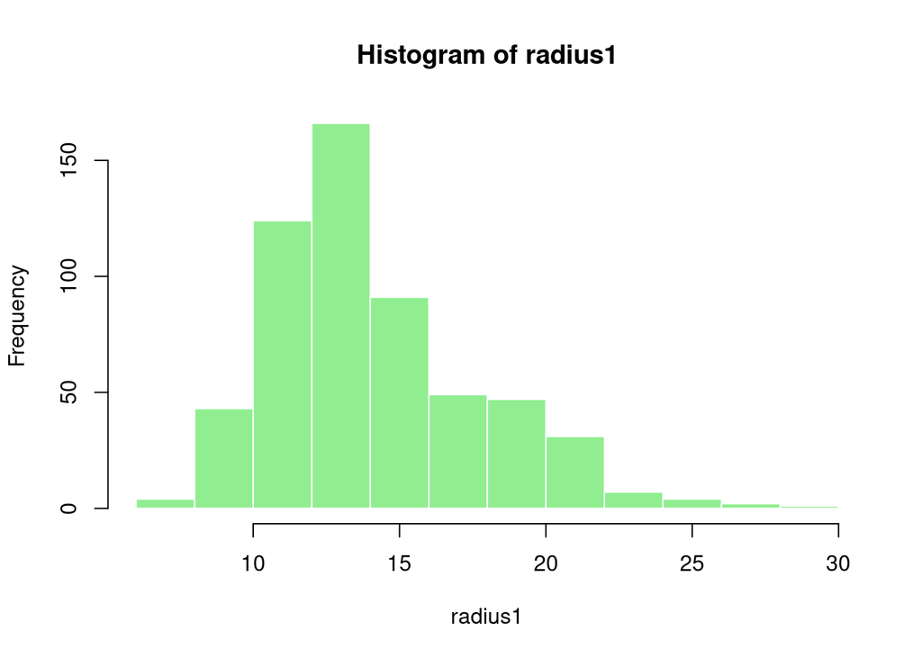

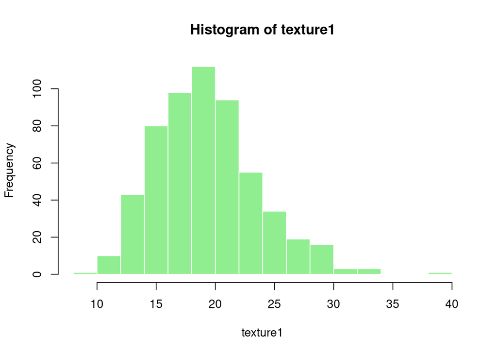

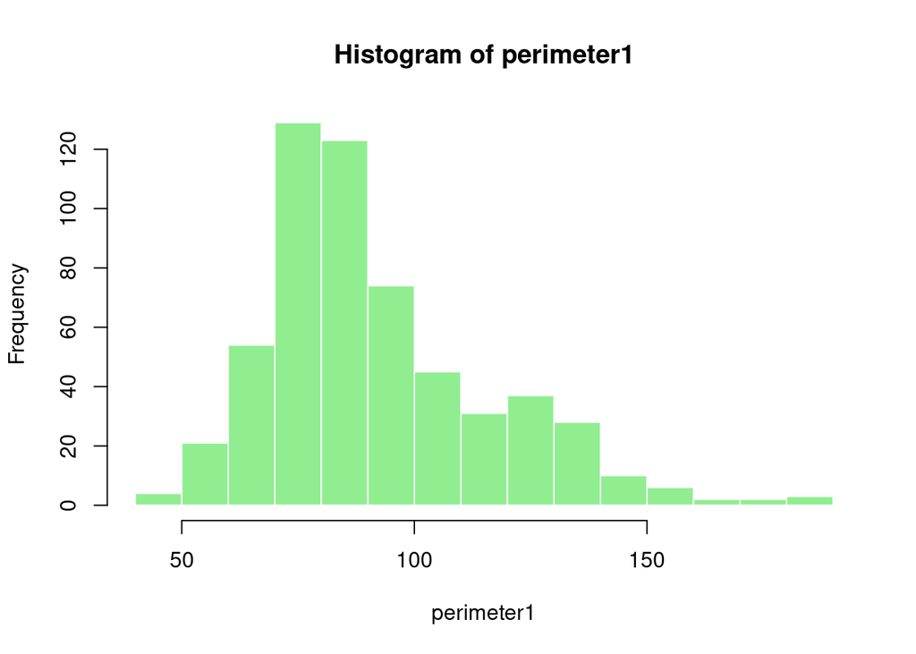

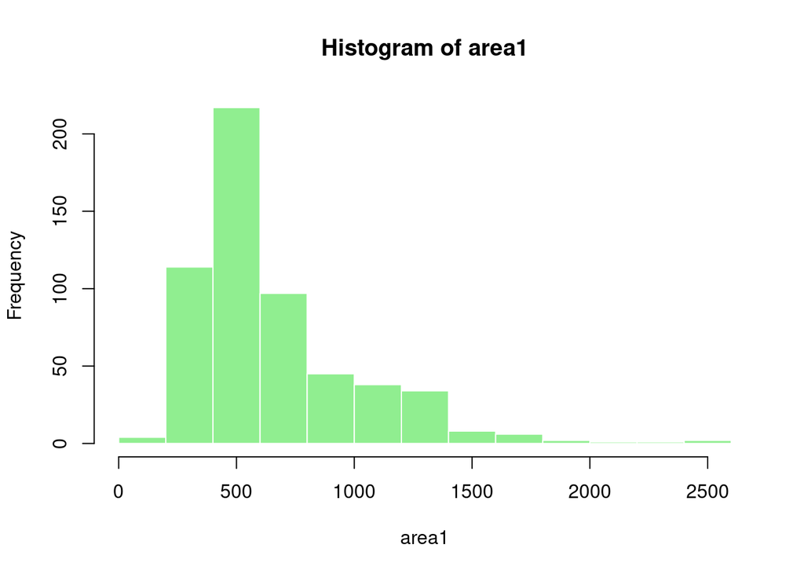

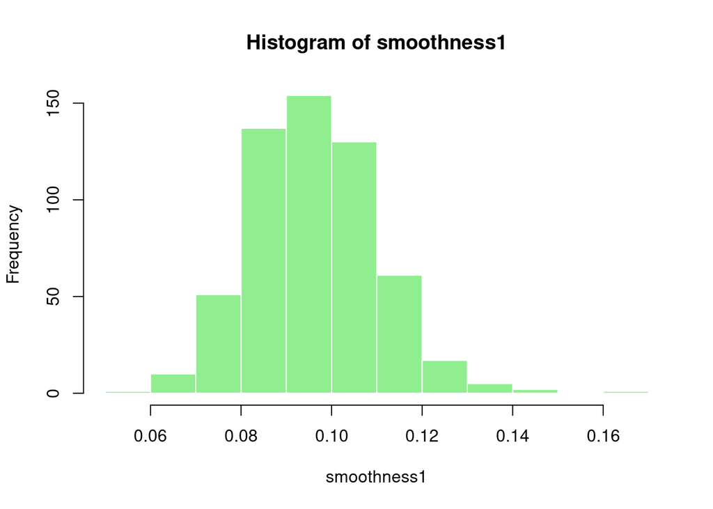

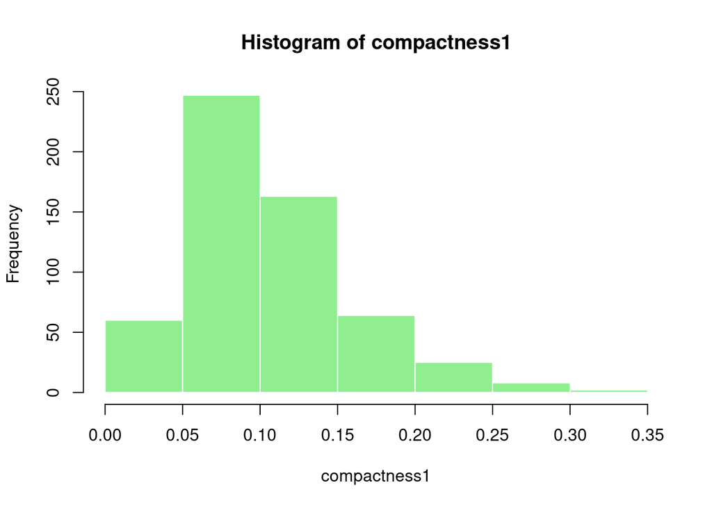

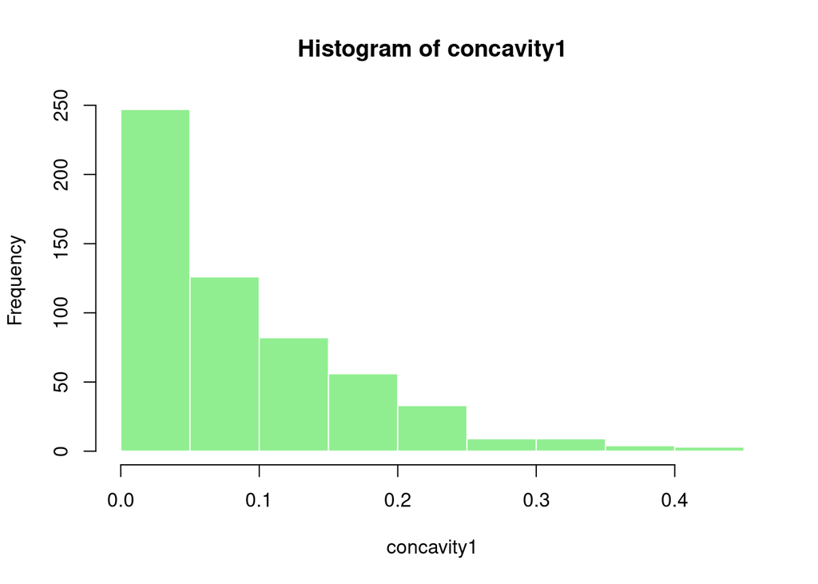

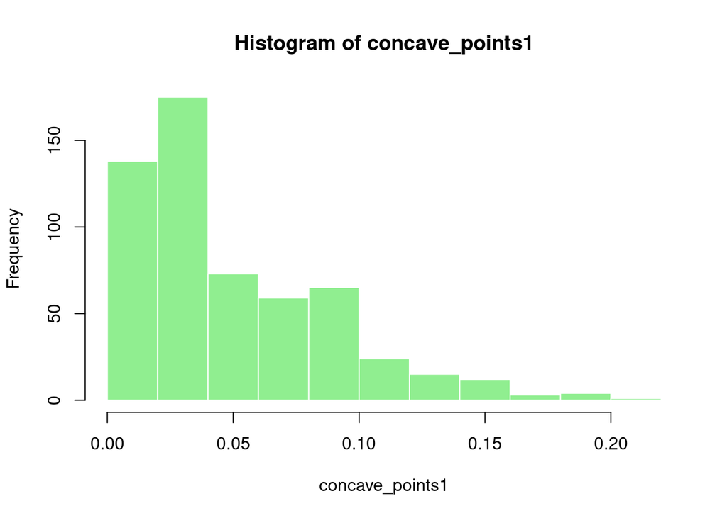

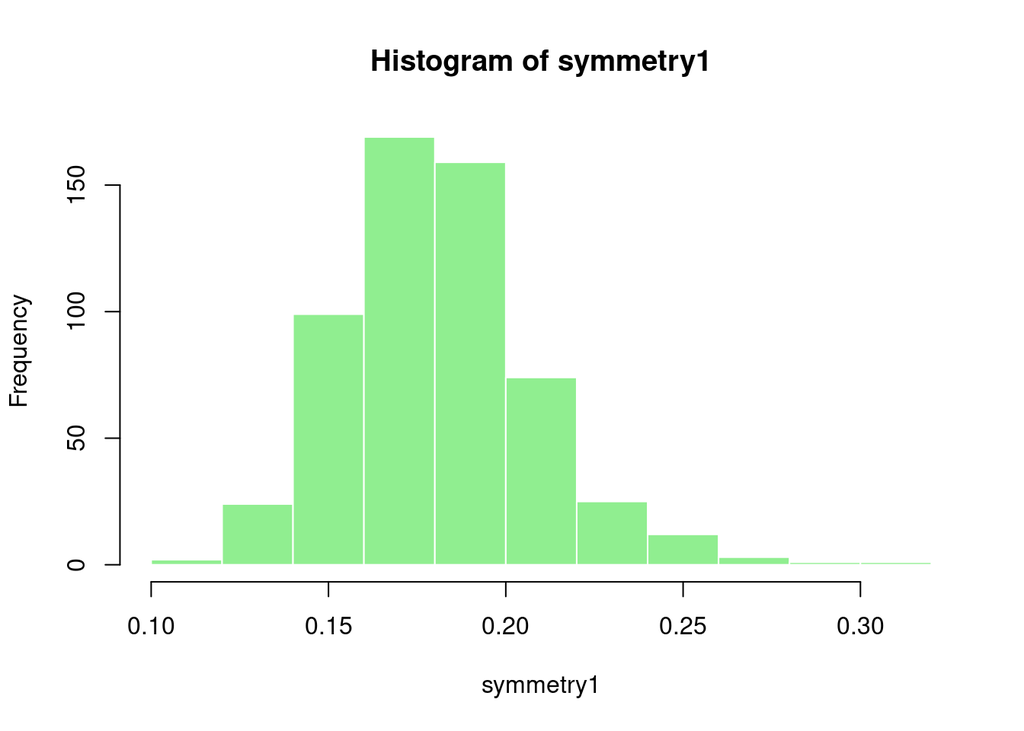

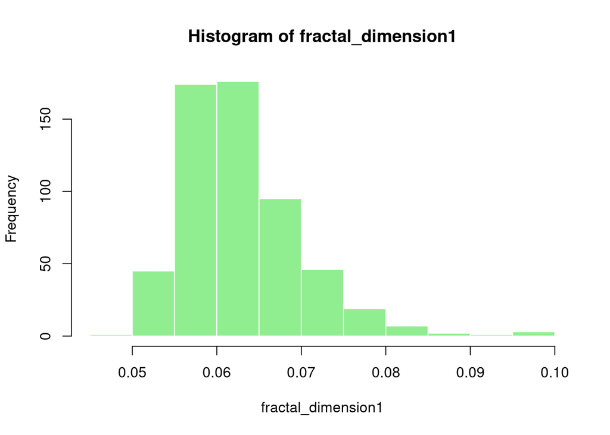

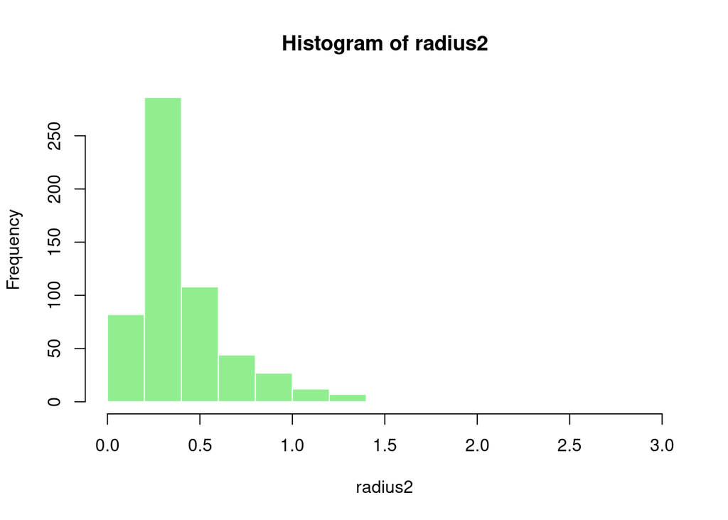

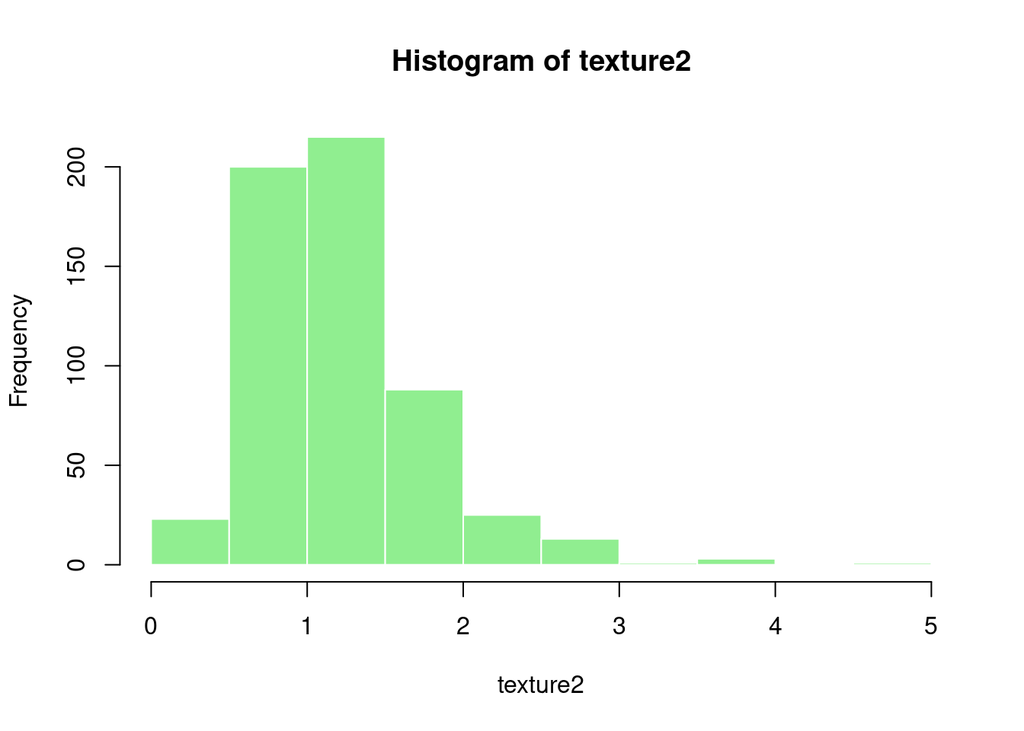

[18 more figures not shown]

```r
par(mfrow = c(1, 1))
for(i in 1:ncol(data)) {
  hist(data[[i]],
       main = paste("Histogram of", names(data)[i]),
       xlab = names(data)[i],
       col = "lightgreen",
       border = "white")
}
```

```r
par(mfrow = c(1,1))
```

Berdasarkan hasil statistik deskriptif, kami menemukan bahwa fitur-fitur terkait ukuran (radius, perimeter, area) menunjukkan variabilitas sangat tinggi, sejalan dengan kenyataan tumor ganas cenderung memiliki ukuran yang besar dan heterogen. Distribusi sebagian besar fitur menceng ke kanan (right-skewed), dengan nilai-nilai mean yang lebih besar daripada median, menunjukkan adanya beberapa kasus ekstrem dengan nilai fitur yang jauh lebih tinggi.

## 3.2 Asumsi Sebelum Reduksi

```r
library(psych)
r <- cor(data)
KMO(r)
```

```
## Kaiser-Meyer-Olkin factor adequacy
## Call: KMO(r = r)
## Overall MSA =  0.83
## MSA for each item =
##            radius1           texture1         perimeter1              area1
##               0.83               0.64               0.85               0.86
##        smoothness1       compactness1         concavity1    concave_points1
##               0.81               0.88               0.89               0.90
##          symmetry1 fractal_dimension1            radius2           texture2
##               0.83               0.83               0.83               0.48
##         perimeter2              area2        smoothness2       compactness2
##               0.84               0.85               0.64               0.87
##         concavity2    concave_points2          symmetry2 fractal_dimension2
##               0.83               0.84               0.58               0.81
##            radius3           texture3         perimeter3              area3
##               0.82               0.60               0.88               0.82
##        smoothness3       compactness3         concavity3    concave_points3
##               0.75               0.85               0.90               0.89
##          symmetry3 fractal_dimension3
##               0.69               0.81
```

```r
bartlett.test(data)
```

```
##
##  Bartlett test of homogeneity of variances
##
## data:  data
## Bartlett's K-squared = 208933, df = 29, p-value < 2.2e-16
```

berdasarkan Hasil analisis maka asumsi PCA terpenuhi karena nilai KMO cukup tinggi dan juga FA terpenuhi karena korelasi cukup untuk membentuk faktor-faktor laten.

## 3.3 PCA (Principal Component Analysis)

### 3.3.1 Nilai Eigen

```r
scale_data = scale(data)
r = cov(scale_data)
pc <- eigen(r)
print(pc$values)
```

```
##  [1] 1.328161e+01 5.691355e+00 2.817949e+00 1.980640e+00 1.648731e+00
##  [6] 1.207357e+00 6.752201e-01 4.766171e-01 4.168948e-01 3.506935e-01
## [11] 2.939157e-01 2.611614e-01 2.413575e-01 1.570097e-01 9.413497e-02
## [16] 7.986280e-02 5.939904e-02 5.261878e-02 4.947759e-02 3.115940e-02
## [21] 2.997289e-02 2.743940e-02 2.434084e-02 1.805501e-02 1.548127e-02
## [26] 8.177640e-03 6.900464e-03 1.589338e-03 7.488031e-04 1.330448e-04
```

Karena nilai eigen pada beberapa variabel sangat kecil yakni <0,1 maka dilakukan reduksi variabel. Reduksi variabel ini dilakukan untuk mempermudah dalam proses analisis dan mengetahui variabel mana saja yang berpengaruh, dengan nilai eigen yang sangat kecil bisa dipastikan bahwa variabel tersebut tidak berpengaruh signifikan. Reduksi dilakukan bagi variabel dengan eigen value <0,1. Sehingga variabel yang tersisa adalah concave_points1 fractal_dimension1 texture2 texture3 smoothness1 symmetry3 fractal_dimension3 smoothness2 concavity2 symmetry1 concavity2 compactness3 concave_points2 compactness2.

```r
pc <- eigen(r)
eigenvalues <- pc$values
eigenvectors <- pc$vectors

selected_components <- which(eigenvalues >= 0.1)

# Hitung kontribusi setiap variabel asli terhadap komponen utama yang dipilih. Kontribusi dihitung berdasarkan nilai absolut dari eigenvectors
contributions <- abs(eigenvectors[, selected_components])

# Pilih variabel asli yang memiliki kontribusi besar.
selected_variables <- apply(contributions, 2, which.max)

# Ambil nama variabel asli yang terpilih
selected_variable_names <- colnames(data)[selected_variables]

# Subset data asli dengan variabel yang terpilih
reduced_data <- data[, selected_variable_names]

# Simpan data yang telah direduksi ke dalam file CSV
write.csv(reduced_data, file = "breast_cancer_reduction.csv", row.names = FALSE)

# Cetak pesan konfirmasi
cat("Data yang telah direduksi telah disimpan dalam file 'breast_cancer_reduction.csv'\n")
```

```
## Data yang telah direduksi telah disimpan dalam file 'breast_cancer_reduction.csv'
```

```r
cat("Variabel yang dipilih:", selected_variable_names, "\n")
```

```
## Variabel yang dipilih: concave_points1 fractal_dimension1 texture2 texture3 smoothness1 symmetry3 fractal_dimension3 smoothness2 concavity2 symmetry1 concavity2 compactness3 concave_points2 compactness2
```

```r
data2 <- read.csv('breast_cancer_reduction.csv')
print(data2)
```

```
##     concave_points1 fractal_dimension1 texture2 texture3 smoothness1 symmetry3
## 1          0.147100            0.07871   0.9053    17.33     0.11840    0.4601
## 2          0.070170            0.05667   0.7339    23.41     0.08474    0.2750
## 3          0.127900            0.05999   0.7869    25.53     0.10960    0.3613
## 4          0.105200            0.09744   1.1560    26.50     0.14250    0.6638
## 5          0.104300            0.05883   0.7813    16.67     0.10030    0.2364
## 6          0.080890            0.07613   0.8902    23.75     0.12780    0.3985
## 7          0.074000            0.05742   0.7732    27.66     0.09463    0.3063
## 8          0.059850            0.07451   1.3770    28.14     0.11890    0.3196
## 9          0.093530            0.07389   1.0020    30.73     0.12730    0.4378
## 10         0.085430            0.08243   1.5990    40.68     0.11860    0.4366
## 11         0.033230            0.05697   1.1870    33.88     0.08206    0.2948
## 12         0.066060            0.06082   0.9849    27.28     0.09710    0.3792
## 13         0.111800            0.07800   3.5680    29.94     0.09740    0.3176
## 14         0.053640            0.05338   1.0780    27.66     0.08401    0.2809
```

[output cut: 1695 more lines]

### 3.3.2 Asumsi setelah Reduksi

```r
r2 <- cor(data2)
KMO(r2)
```

```
## Error in solve.default(r) :
##   Lapack routine dgesv: system is exactly singular: U[11,11] = 0
```

```
## matrix is not invertible, image not found
```

```
## Kaiser-Meyer-Olkin factor adequacy
## Call: KMO(r = r2)
## Overall MSA =  0.5
## MSA for each item =
##    concave_points1 fractal_dimension1           texture2           texture3
##                0.5                0.5                0.5                0.5
##        smoothness1          symmetry3 fractal_dimension3        smoothness2
##                0.5                0.5                0.5                0.5
##         concavity2          symmetry1       concavity2.1       compactness3
##                0.5                0.5                0.5                0.5
##    concave_points2       compactness2
##                0.5                0.5
```

```r
bartlett.test(data2)
```

```
##
##  Bartlett test of homogeneity of variances
##
## data:  data2
## Bartlett's K-squared = 59510, df = 13, p-value < 2.2e-16
```

Asumsi setelah reduksi variabel menunjukan nilai KMO yang dibawah 0,6 Maka dari itu tidak dapat dilakukan Factor analysis dengan Maximum likelihood( ML) karena korelasi antar variabel lemah dan tidak cocok untuk FA dengan ML.

### 3.3.3 Parallel Analysis

```
## In smc, smcs < 0 were set to .0
## In smc, smcs < 0 were set to .0
## In smc, smcs < 0 were set to .0
```

```
## In factor.scores, the correlation matrix is singular, the pseudo inverse is  used
```

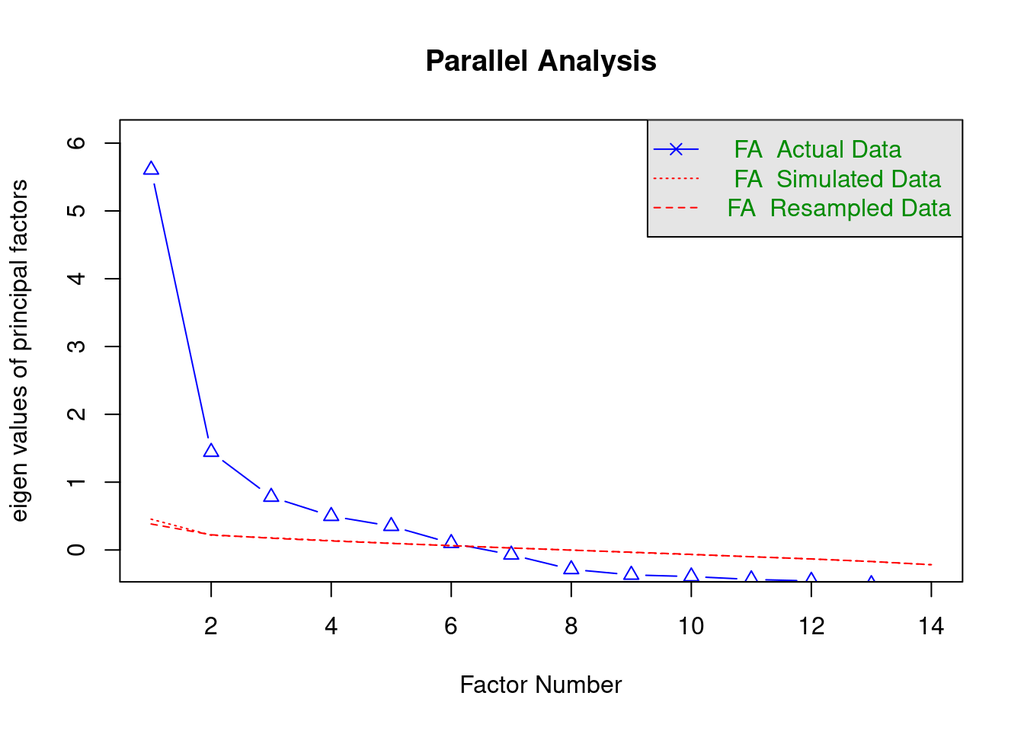

```
## Parallel analysis suggests that the number of factors =  6  and the number of components =  NA
```

```r
scale_data2 = scale(data2)
pa_result <- fa.parallel(scale_data2, fa = "fa", n.iter = 100, show.legend = TRUE, main = "Parallel Analysis")
```

Berdasarkan hasil parallel analysis, disebutkan bahwa jumlah pc yang disarankan yakni 6. Kami menggunakan pendekatan FA dalam menentukan jumlah pc untuk mempermudah proses analisis dan masih tetap memperhatikan eigenvalues. Berdasarkan plot parallel analysis nilai yang ideal adalah 6, tetapi bisa dilihat bahwa titik pada factor number 4, 5, dan 6 tidak terlalu berbeda. Sehingga kami memilih nilai pc adalah 4 karena setelah nilai 4 penurunan yang terjadi sangat minim dan tidak signifikan.

### 3.3.4 Hasil dan Pembahasan PCA

```r
pca_result <- principal(scale_data2, nfactors = 4, rotate = "none")
print(pca_result)
```

```
## Principal Components Analysis
## Call: principal(r = scale_data2, nfactors = 4, rotate = "none")
## Standardized loadings (pattern matrix) based upon correlation matrix
##                     PC1   PC2   PC3   PC4   h2    u2 com
## concave_points1    0.68 -0.18 -0.33  0.05 0.61 0.392 1.6
## fractal_dimension1 0.69 -0.02  0.56 -0.02 0.79 0.208 1.9
## texture2           0.19  0.53  0.02  0.74 0.86 0.140 2.0
## texture3           0.24 -0.13 -0.52  0.72 0.86 0.140 2.2
## smoothness1        0.63 -0.24  0.43  0.15 0.66 0.337 2.2
## symmetry3          0.54 -0.65  0.02  0.10 0.73 0.275 2.0
## fractal_dimension3 0.76 -0.35  0.15 -0.05 0.72 0.280 1.5
## smoothness2        0.32  0.54  0.56  0.23 0.76 0.238 3.0
## concavity2         0.79  0.42 -0.22 -0.25 0.92 0.083 1.9
## symmetry1          0.67 -0.30  0.24  0.17 0.62 0.376 1.8
## concavity2.1       0.79  0.42 -0.22 -0.25 0.92 0.083 1.9
## compactness3       0.80 -0.41 -0.23 -0.04 0.87 0.132 1.7
## concave_points2    0.76  0.39 -0.19 -0.13 0.79 0.213 1.7
## compactness2       0.86  0.27 -0.11 -0.13 0.84 0.162 1.3
##
##                        PC1  PC2  PC3  PC4
## SS loadings           6.09 2.05 1.47 1.34
## Proportion Var        0.44 0.15 0.10 0.10
## Cumulative Var        0.44 0.58 0.69 0.78
## Proportion Explained  0.56 0.19 0.13 0.12
## Cumulative Proportion 0.56 0.74 0.88 1.00
##
## Mean item complexity =  1.9
## Test of the hypothesis that 4 components are sufficient.
##
## The root mean square of the residuals (RMSR) is  0.08
##  with the empirical chi square  588.13  with prob <  5.3e-98
##
## Fit based upon off diagonal values = 0.97
```

Dari hasil PCA, terdapat 4 komponen yakni PC1, PC2, PC3, dan PC4. Dari total varians keempat PC yakni 78% menunjukkan bahwa hasil sudah cukup baik karena sudah bisa menangkap sebagian besar informasi dalam data.

```r
print(pca_result$loadings)
```

```
##
## Loadings:
##                    PC1    PC2    PC3    PC4
## concave_points1     0.681 -0.183 -0.328
## fractal_dimension1  0.695         0.556
## texture2            0.195  0.526         0.738
## texture3            0.242 -0.127 -0.523  0.715
## smoothness1         0.632 -0.239  0.431  0.147
## symmetry3           0.543 -0.648         0.101
## fractal_dimension3  0.758 -0.348  0.150
## smoothness2         0.321  0.542  0.558  0.234
## concavity2          0.795  0.417 -0.219 -0.253
## symmetry1           0.669 -0.302  0.239  0.166
## concavity2.1        0.795  0.417 -0.219 -0.253
## compactness3        0.803 -0.409 -0.234
## concave_points2     0.761  0.394 -0.189 -0.131
## compactness2        0.860  0.266 -0.109 -0.125
##
##                  PC1   PC2   PC3   PC4
## SS loadings    6.090 2.050 1.465 1.338
## Proportion Var 0.435 0.146 0.105 0.096
## Cumulative Var 0.435 0.581 0.686 0.782
```

1.PC1 Berisi variabel yang paling banyak, yakni 6 variabel dan menjelaskan 44% dari variansi data yaitu compactness2, compactness3, concavity2, concavity2.1, concav_points2, fractal_dimension3. PC1 merepresentasikan sejauh mana bentuk sel tidak teratur dan kompleks. Variabel-variabel ini berkaitan dengan tingkat kekasaran, cekungan, dan kejanggalan bentuk pada tepi sel. Nilai tinggi pada PC1 dapat diasosiasikan dengan kemungkinan keganasan (malignant) karena sel kanker cenderung memiliki bentuk tidak beraturan dan tepi yang tidak halus.

2.PC2 Berisi 3 variabel yaitu texture2, smoothness2, dan symmetry3. PC2 mencerminkan kualitas tekstur dan keseimbangan bentuk sel. Variabel texture dan smoothness berhubungan dengan kerataan permukaan dan distribusi pola dalam citra, sedangkan symmetry berkaitan dengan kesimetrian bentuk sel. Nilai ekstrem pada PC2 mungkin menunjukkan anomali dalam pola pertumbuhan sel.

3.PC3 Berisi 3 variabel yaitu fractal_dimension1, smoothness2, dan texture3. Komponen ini menyiratkan tingkat kerumitan permukaan sel secara mikroskopik. Dimensi fractal_dimension mengukur seberapa kompleks struktur sel di bawah pembesaran. Dalam konteks klinis, semakin tinggi kompleksitas fraktal, bisa jadi mengindikasikan perubahan patologis pada struktur jaringan.

4.PC4 Berisi 2 variabel yakni texture2 dan texture3. PC4 menangkap informasi murni mengenai variasi tekstur dalam citra sel. Ini menunjukkan bahwa beberapa aspek tekstur bersifat independen dari bentuk dan ukuran, namun tetap penting dalam membedakan antara jaringan sehat dan jaringan abnormal.

```r
library(FactoMineR)
p<-4
pca_result <- PCA(scale_data2,
                  scale.unit = TRUE,
                  graph = FALSE,
                  ncp=p)
```

### 3.3.5 Rangkuman PCA

```r
pca_result$eig          # vs print(cumvar)
```

```
##           eigenvalue percentage of variance cumulative percentage of variance
## comp 1  6.090040e+00           4.350028e+01                          43.50028
## comp 2  2.049913e+00           1.464224e+01                          58.14252
## comp 3  1.465445e+00           1.046747e+01                          68.60999
## comp 4  1.337832e+00           9.555943e+00                          78.16593
## comp 5  9.796944e-01           6.997817e+00                          85.16375
## comp 6  7.209039e-01           5.149314e+00                          90.31306
## comp 7  4.056673e-01           2.897624e+00                          93.21069
## comp 8  3.147568e-01           2.248263e+00                          95.45895
## comp 9  1.867416e-01           1.333869e+00                          96.79282
## comp 10 1.703105e-01           1.216504e+00                          98.00932
## comp 11 1.377685e-01           9.840609e-01                          98.99338
## comp 12 9.801563e-02           7.001117e-01                          99.69349
## comp 13 4.291101e-02           3.065072e-01                         100.00000
## comp 14 3.828352e-32           2.734537e-31                         100.00000
```

```r
pca_result$svd$V        # vs pc$vectors
```

```
##             [,1]        [,2]        [,3]        [,4]
##  [1,] 0.27604011 -0.12795710 -0.27060525  0.04671006
##  [2,] 0.28145218 -0.01374375  0.45890831 -0.01609556
##  [3,] 0.07883510  0.36768099  0.01772464  0.63816717
##  [4,] 0.09820947 -0.08848593 -0.43234546  0.61820537
##  [5,] 0.25605085 -0.16689357  0.35564851  0.12674753
##  [6,] 0.22019003 -0.45235439  0.01417345  0.08696127
##  [7,] 0.30698034 -0.24329589  0.12406872 -0.03890810
##  [8,] 0.13002382  0.37856768  0.46067337  0.20216950
##  [9,] 0.32204772  0.29090504 -0.18108836 -0.21903839
## [10,] 0.27122761 -0.21101943  0.19776671  0.14346489
## [11,] 0.32204772  0.29090504 -0.18108836 -0.21903839
## [12,] 0.32540167 -0.28564935 -0.19341459 -0.03226156
## [13,] 0.30848737  0.27501959 -0.15615928 -0.11297014
## [14,] 0.34855854  0.18553352 -0.09025997 -0.10848722
```

```r
pca_result$ind['coord'] # vs head(scores)
```

```
## $coord
##             Dim.1        Dim.2        Dim.3        Dim.4
## 1    5.3120765983 -2.868995551  1.114262712 -1.100681673
## 2   -1.0412118033 -0.587747932 -0.679330521 -0.754231296
## 3    2.3727642365 -1.220419295 -0.894652093 -0.502182375
## 4    9.4370237643 -4.952839105  3.079834640  0.393581963
## 5    0.7462906840  1.547468043  0.281194983 -1.538182270
## 6    3.4196353231 -2.521922879  1.718594318 -0.205557842
## 7   -0.6719555245 -1.192107480 -0.949505116 -0.225169659
## 8    2.4244882925 -1.137589986  1.709066460  0.917825884
## 9    3.6506614698 -3.056751266  0.756743156  0.740978156
## 10   8.2599610063 -3.262142722 -0.236616248  1.058278734
## 11  -2.0401500425 -0.687382417 -1.311217041  0.809522660
## 12   1.5920310248 -1.787857061 -0.790856685 -0.180209516
## 13   6.3738847504  2.612257846 -1.571331926  1.506805192
```

[output cut: 556 more lines]

### 3.3.6 Biplot

```r
library(factoextra)
```

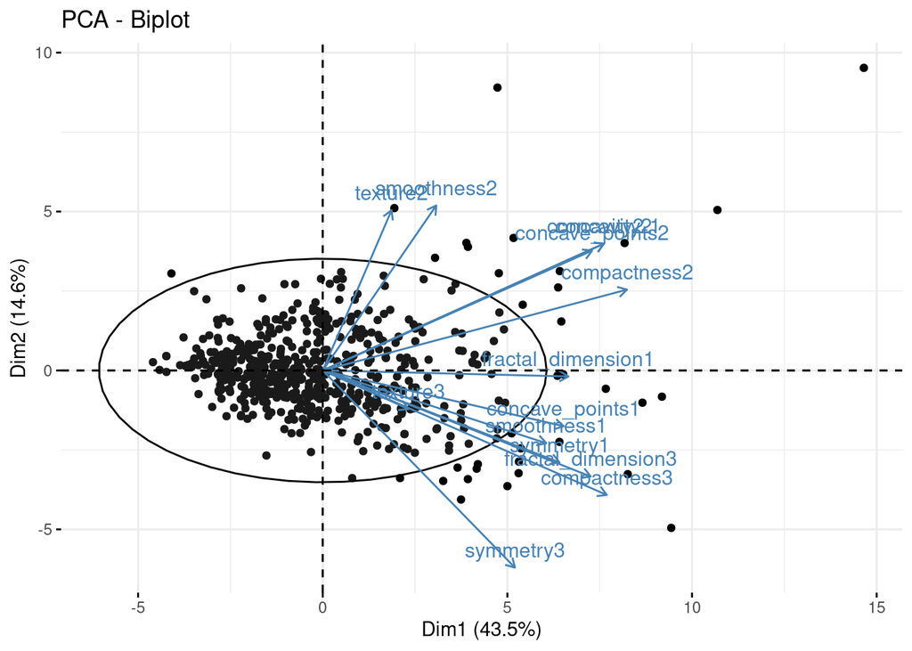

```r
# Buat biplot
fviz_pca_biplot(pca_result,
                geom.ind = "point",  # Tampilkan individu sebagai titik
                addEllipses = TRUE)
```

### 3.3.7 Corelation circel

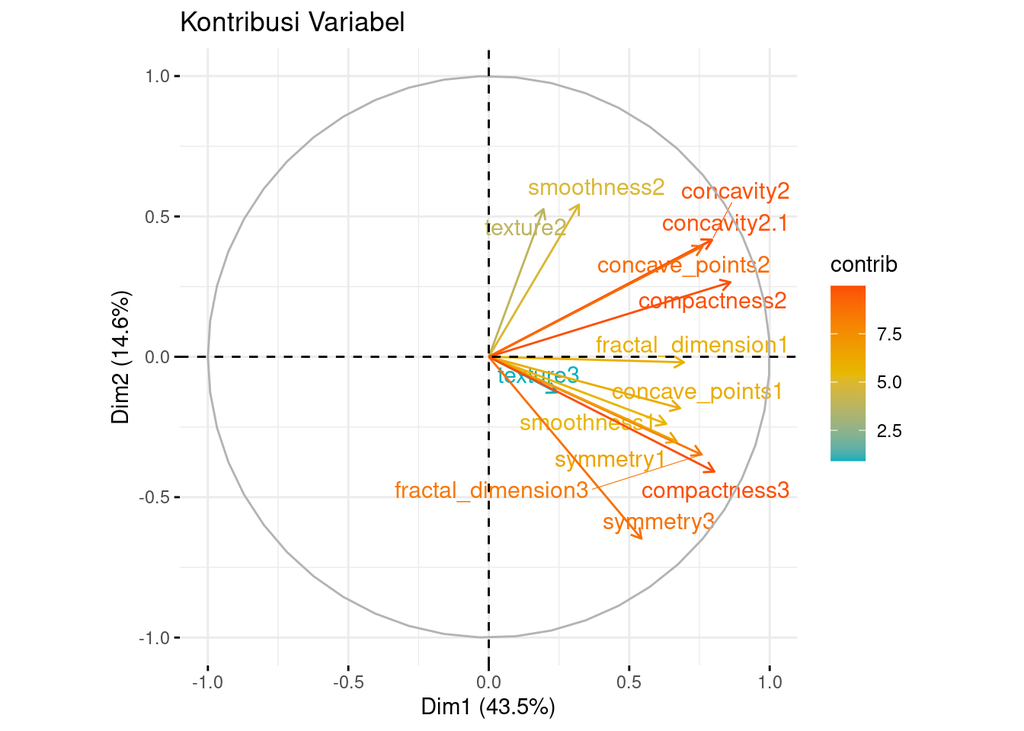

```r
# Instal dan muat paket factoextra (jika belum)

library(factoextra)

# Buat plot kontribusi variabel
contrib_circle <- fviz_pca_var(pca_result,
                               col.var = "contrib",  # Warna berdasarkan kontribusi
                               gradient.cols = c("#00AFBB", "#E7B800", "#FC4E07"),  # Gradien warna
                               repel = TRUE) +  # Hindari tumpang tindih label
  ggtitle("Kontribusi Variabel")  # Judul plot

# Tampilkan plot
plot(contrib_circle)
```

```r
sum(is.na(scale_data2))  # Cek nilai NA
```

```
## [1] 0
```

```r
sum(is.nan(scale_data2))  # Cek nilai NaN
```

```
## [1] 0
```

```r
sum(is.infinite(scale_data2))  # Cek nilai Inf
```

```
## [1] 0
```

### 3.3.8 Nilai eigen

```r
r <- cor(scale_data2)  # Hitung matriks korelasi
eigen(r)$values  # Periksa eigenvalues
```

```
##  [1] 6.090040e+00 2.049913e+00 1.465445e+00 1.337832e+00 9.796944e-01
##  [6] 7.209039e-01 4.056673e-01 3.147568e-01 1.867416e-01 1.703105e-01
## [11] 1.377685e-01 9.801563e-02 4.291101e-02 8.326673e-17
```

Karena hasil uji setelah reduksi tidak memenuhi asumsi pada KMO harus≥ 0.6 yaitu nilai KMO setelah direduksi adalah 0,5. Maka dari itu tidak dapat dilakukan Factor analysis dengan Maximum likelihood( ML) karena korelasi antar variabel lemah dan tidak cocok untuk FA dengan ML. Maka dari itu menggunakan metode Principal Axis Factoring(PA) pada FA untuk loading. Nilai eigen value paling dominan adalah yaitu 6.09, 2.05 , 1.47 , 1.34 ini berarti empat faktor pertama yang menjelaskan sebagian besar varians dalam data.

### 3.3.9 Interpretasi hasil FA

```r
fa_result <- fa(r = scale_data2,
                nfactors = 4,  # Jumlah faktor yang ingin diekstrak
                rotate = "varimax",  # Metode rotasi
                fm = "pa")  # Metode ekstraksi (maximum likelihood)
```

```
## In smc, smcs < 0 were set to .0
```

```
## maximum iteration exceeded
```

```
## In factor.scores, the correlation matrix is singular, the pseudo inverse is  used
```

```r
# Tampilkan hasil analisis faktor
print(fa_result)
```

```
## Factor Analysis using method =  pa
## Call: fa(r = scale_data2, nfactors = 4, rotate = "varimax", fm = "pa")
## Standardized loadings (pattern matrix) based upon correlation matrix
##                     PA1   PA2   PA3   PA4   h2     u2 com
## concave_points1    0.45  0.47 -0.15  0.29 0.52  0.475 2.9
## fractal_dimension1 0.25  0.68  0.52 -0.26 0.86  0.138 2.5
## texture2           0.11 -0.14  0.73  0.68 1.03 -0.026 2.1
## texture3           0.06  0.16 -0.07  0.66 0.47  0.531 1.2
## smoothness1        0.15  0.65  0.25 -0.01 0.51  0.493 1.4
## symmetry3          0.05  0.73 -0.19  0.16 0.59  0.408 1.2
## fractal_dimension3 0.29  0.77  0.05 -0.02 0.69  0.314 1.3
## smoothness2        0.21  0.07  0.63 -0.08 0.45  0.548 1.3
## concavity2         0.94  0.18  0.14  0.01 0.93  0.069 1.1
## symmetry1          0.20  0.65  0.14  0.11 0.50  0.500 1.4
## concavity2.1       0.94  0.18  0.14  0.01 0.93  0.069 1.1
## compactness3       0.43  0.77 -0.27  0.24 0.90  0.096 2.1
## concave_points2    0.79  0.21  0.17  0.11 0.71  0.295 1.3
## compactness2       0.77  0.39  0.19  0.08 0.79  0.209 1.7
##
##                        PA1  PA2  PA3  PA4
## SS loadings           3.64 3.57 1.52 1.16
## Proportion Var        0.26 0.25 0.11 0.08
## Cumulative Var        0.26 0.51 0.62 0.71
## Proportion Explained  0.37 0.36 0.15 0.12
## Cumulative Proportion 0.37 0.73 0.88 1.00
##
## Mean item complexity =  1.6
## Test of the hypothesis that 4 factors are sufficient.
##
## df null model =  91  with the objective function =  33.14 with Chi Square =  18638.85
## df of  the model are 41  and the objective function was  22.4
##
## The root mean square of the residuals (RMSR) is  0.06
## The df corrected root mean square of the residuals is  0.09
##
## The harmonic n.obs is  569 with the empirical chi square  405.54  with prob <  1.7e-61
## The total n.obs was  569  with Likelihood Chi Square =  12541.17  with prob <  0
##
## Tucker Lewis Index of factoring reliability =  -0.503
## RMSEA index =  0.732  and the 90 % confidence intervals are  0.722 0.743
## BIC =  12281.07
## Fit based upon off diagonal values = 0.98
## Measures of factor score adequacy
##                                                    PA1  PA2  PA3  PA4
## Correlation of (regression) scores with factors   0.98 0.97 0.97 0.99
## Multiple R square of scores with factors          0.96 0.95 0.95 0.98
## Minimum correlation of possible factor scores     0.91 0.90 0.90 0.96
```

Analisis faktor yang dilakukan menggunakan metode Principal Axis Factoring (PA) dengan rotasi Varimax menghasilkan empat faktor utama yang menjelaskan 71% dari total varians data. Namun, dari hasil uji kecocokan model, analisis ini menunjukkan beberapa kelemahan. Nilai RMSEA sebesar 0.732 menunjukkan bahwa model tidak memiliki kecocokan yang baik, sementara Tucker Lewis Index (TLI) negatif (-0.503) menandakan kurangnya keandalan dalam faktor yang terbentuk. Chi-Square test menunjukkan signifikansi yang sangat tinggi (p < 0), yang mengindikasikan model kurang sesuai dengan data.Hal ini disebabkan karena FA tidak memenuhi asumsi.

[figure not shown]

```r
load <- fa_result$loadings

plot(load[,c(1,3)],type="n") # set up plot
text(load[,c(1,3)],labels=names(data),cex=.7)
```

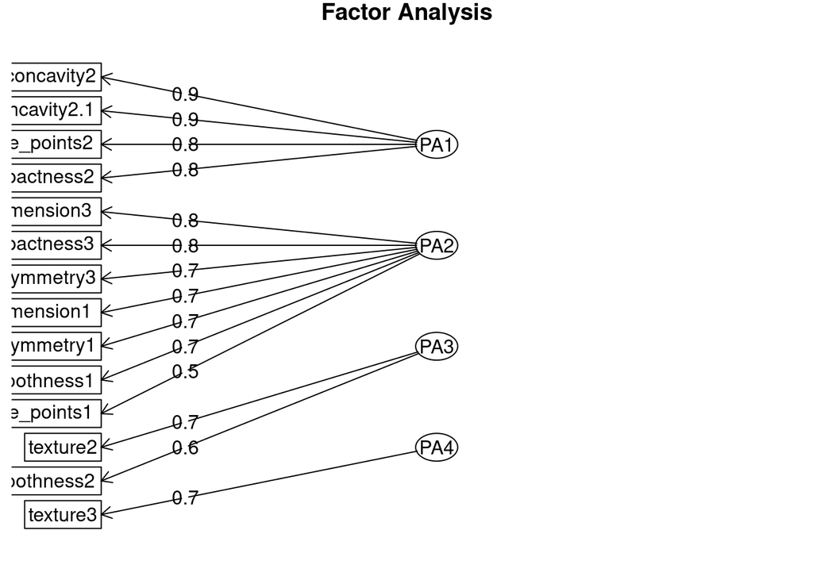

```r
fa.diagram(load)
```

Menunjukan variabel dengan empat faktor laten (PA1, PA2, PA3, dan PA4)berdasarkan factor loading 1.PA 1 memiliki hubungan kuat dengan concavity2, concavity2.1, concave_points2, dan compactness2 menunjukan keterkaitan terhadap Keharusan Struktural dan Morfologi Sel Tumor. pada data FNA PA1 sejauh mana batas sel tumor melengkung ke dalam dan seberapa padat bentuk selnya. Faktor ini dapat dikaitkan dengan keagresifan tumor.

2.PA2 memiliki factor loadings sekitar 0.7 - 0.8 terhadap fractal_dimension3, compactness3, symmetry3, fractal_dimension1, dan symmetry1, maka faktor ini kemungkinan besar terkait dengan kompleksitas dan simetri sel tumor dalam dataset FNA kanker payudara.Faktor ini bisa menjadi indikator tingkat keganasan.

3.PA3 dan PA4 memiliki variabel yang terkait dengan smoothness dan texture, maka faktor-faktor ini kemungkinan besar berhubungan dengan karakteristik permukaan dan pola tekstur sel tumor.

Jadi Analisis faktor di atas mengelompokkan variabel berdasarkan karakteristik morfologi sel tumor, yang berhubungan dengan keganasan tumor.

# 4 BAB Kesimpulan

Di sisi lain, FA menghasilkan empat faktor utama (PA1, PA2, PA3, PA4) yang menjelaskan 71% varians total. Faktor-faktor ini mengelompokkan variabel berdasarkan karakteristik morfologi sel tumor, seperti keharusan struktural, kompleksitas, simetri, dan tekstur. Namun, model FA memiliki kelemahan dalam kecocokan dengan data, seperti nilai RMSEA yang tinggi dan TLI yang negatif, menunjukkan bahwa model kurang sesuai. Meskipun demikian, FA tetap memberikan gambaran tentang hubungan antara variabel-variabel morfologi sel tumor yang dapat digunakan untuk memahami tingkat keganasan tumor.

Secara keseluruhan, PCA lebih unggul dalam hal kecocokan model dan kemudahan interpretasi, sementara FA memberikan wawasan tambahan tentang hubungan laten antara variabel. Untuk analisis lebih lanjut, PCA direkomendasikan karena hasilnya lebih stabil dan dapat diandalkan. Namun, FA tetap dapat digunakan sebagai pendekatan alternatif jika peneliti ingin mengeksplorasi hubungan laten antara variabel, meskipun perlu dilakukan perbaikan model atau pertimbangan metode lain yang lebih sesuai dengan karakteristik data. Kedua metode ini saling melengkapi dalam memberikan pemahaman yang lebih mendalam tentang karakteristik morfologi sel tumor dan dapat digunakan untuk mendukung diagnosis dan analisis klinis terkait kanker payudara

# 5 Daftar Pustaka

World Health Organization: WHO, “Breast Cancer,” World Health Organization: WHO, 13 March 2024 https://www.who.int/news-room/fact-sheets/detail/breast-cancer [accessed 23 March 2025] Agung Winasis, and Ratna Djuwita, “Obesitas Dan Kanker Payudara : Literature Review,” Media Publikasi Promosi Kesehatan Indonesia (MPPKI), 6.8 (2023), pp. 1501–8, doi:10.56338/mppki.v6i8.3501 Tagar, Esteem, James Kpolugbo, Afokeoghene G. Tagar, Ehiremhen Ozah, Lucky A. Ehiagwina, and Orume Enegbuya, “Fine Needle Aspiration in the Evaluation of Patients with Suspected Breast Cancer in a Suburban Nigerian Teaching Hospital: A Five-Year Review,” Journal of Breast Cancer Research, Volume 4.Issue 1 (2024), pp. 11–16, doi:10.46439/breastcancer.4.022 Greenacre, Michael, Patrick J. F. Groenen, Trevor Hastie, Alfonso Iodice D’Enza, Angelos Markos, and Elena Tuzhilina, “Principal Component Analysis,” Nature Reviews Methods Primers, 2.1 (2022), pp. 1–21, doi:10.1038/s43586-022-00184-w Rijkure, Astrida, “Use of Multifactor Statistical, Exploratory Factor Analysis (EFA) in Port Efficiency Assessment Methods,” in Transport Means 2024. Proceedings of the 28th International Scientific Conference (KTU leidykla “Technologija„, 2024) https://doi.org/10.5755/e01.2351-7034.2024.p793-798 [accessed 23 March 2025]